# seaborn_datavisualizations_and_exploration

### Requirements

```python
import numpy as np
import pandas as pd
import seaborn as sns
import matplotlib.pyplot as plt
%matplotlib inline
```

### Question #1

```python
df1 = pd.read_csv('studentsperformance.csv')
df1.head()
```

|  | gender | race/ethnicity | parental level of education | lunch | test preparation course | math score | reading score | writing score |
| --- | --- | --- | --- | --- | --- | --- | --- | --- |
| 0 | female | group B | bachelor's degree | standard | none | 72 | 72 | 74 |
| 1 | female | group C | some college | standard | completed | 69 | 90 | 88 |
| 2 | female | group B | master's degree | standard | none | 90 | 95 | 93 |
| 3 | male | group A | associate's degree | free/reduced | none | 47 | 57 | 44 |
| 4 | male | group C | some college | standard | none | 76 | 78 | 75 |

```python
df1.info()
```

```
<class 'pandas.core.frame.DataFrame'>
RangeIndex: 1000 entries, 0 to 999
Data columns (total 8 columns):
gender                         1000 non-null object
race/ethnicity                 1000 non-null object
parental level of education    1000 non-null object
lunch                          1000 non-null object
test preparation course        1000 non-null object
math score                     1000 non-null int64
reading score                  1000 non-null int64
writing score                  1000 non-null int64
dtypes: int64(3), object(5)
memory usage: 62.6+ KB
```

#### Examples of Plots of One Variable

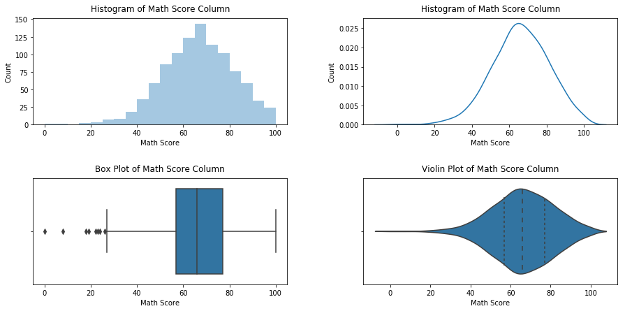

```python
plt.figure(figsize = [15,7])
plt.subplots_adjust(hspace = 0.5, wspace = 0.3)

plt.subplot(2, 2, 1)
base_color = sns.color_palette()[0]
plot1 = sns.distplot(df1['math score'], color = base_color, kde = False, bins = 20)
plt.title('Histogram of Math Score Column', pad = 10)
plt.xlabel("Math Score")
plt.ylabel("Count")

plt.subplot(2, 2, 2)
plot2 = sns.distplot(df1['math score'], color = base_color, hist = False)
plt.title('Histogram of Math Score Column', pad = 10)
plt.xlabel("Math Score")
plt.ylabel("Count")

plt.subplot(2, 2, 3)
plot3 = sns.boxplot(data = df1, x = 'math score', color = base_color)
plt.title('Box Plot of Math Score Column', pad = 10)
plt.xlabel("Math Score")

plt.subplot(2, 2, 4)
plot4 = sns.violinplot(data = df1, x = 'math score', color = base_color, inner = 'quartile')
plt.title('Violin Plot of Math Score Column', pad = 10)
plt.xlabel("Math Score");
```

From the plots above, all four succesfully highlight the distribution of the numeric field 'math score'. However, two of the plots (Box and Violin plots) are able to convey additional valuable information about the data in terms of quartiles and a measure of central tendency (median). In my opinion the fact that the box plot shows potential outliers in the plot gives this type of plot an edge over the violin plot

#### Examples of Plots of Two Continous Variables

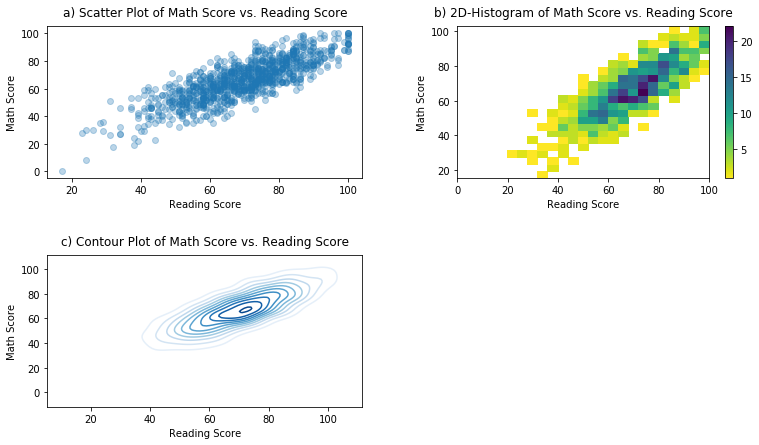

```python
plt.figure(figsize = [13, 7])
plt.subplots_adjust(hspace = 0.5, wspace = 0.3)

plt.subplot(2, 2, 1)
sns.regplot(data = df1, x = 'reading score', y = 'math score', fit_reg = False, scatter_kws={'alpha':0.3}, ci = False)
plt.title('a) Scatter Plot of Math Score vs. Reading Score', pad = 10)
plt.xlabel("Reading Score")
plt.ylabel("Math Score")

plt.subplot(2, 2, 2)
bins_x = np.arange(0, 100 + 4, 4)
bins_y = np.arange(15, 100 + 4, 4)
plt.hist2d(data = df1, x = 'reading score', y = 'math score', bins = [bins_x, bins_y], cmap = 'viridis_r', cmin = 0.2)
plt.colorbar()
plt.title('b) 2D-Histogram of Math Score vs. Reading Score', pad = 10)
plt.xlabel("Reading Score")
plt.ylabel("Math Score")

plt.subplot(2, 2, 3)
x = df1['reading score']
y = df1['math score']
sns.kdeplot(x, y, cmap = "Blues")
plt.title('c) Contour Plot of Math Score vs. Reading Score', pad = 10)
plt.xlabel("Reading Score")
plt.ylabel("Math Score");
```

From the plots above, a positive relationship between the plotted contious variables can be inferred, however certain elements in the plots can provide additional information about the data. In plot a), the 'math score' and 'reading score' for each student in the dataset were plotted against each other and the resulting plot highlights very clearly the correlation between the two variables. In plot b), an additional element was included to display the 'density' of points associated data points, the color intensity correlates to higher count of data points. In the last plot (c), contours were added to give a sense of density besides the known positive correlation between the variables. For the data being analyzed, the regular scatter plot is the simplest and clearest way to represent this interaction

#### Examples of Plots of One Continous Variable and One Categorical Variable

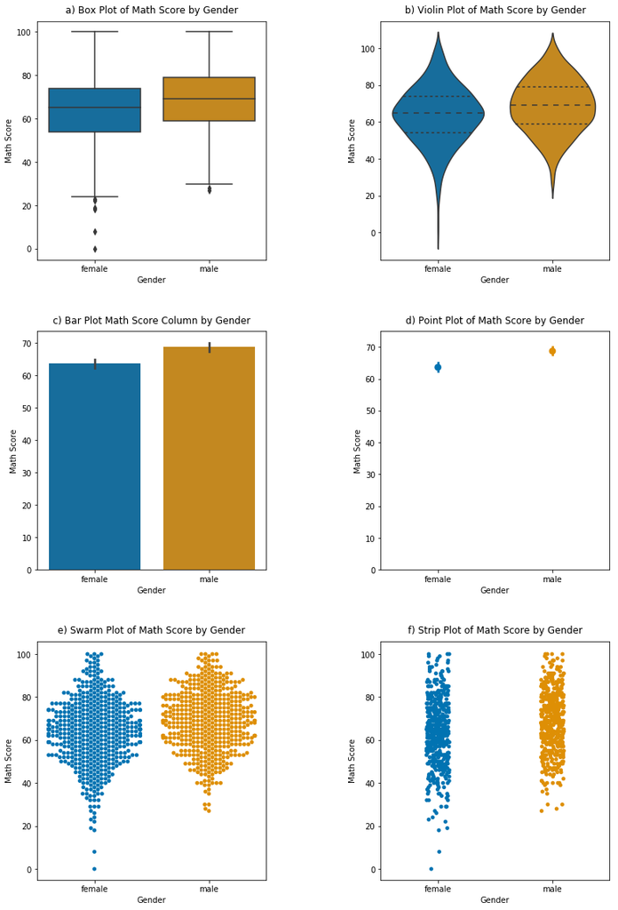

```python
plt.figure(figsize = [13, 20])
plt.subplots_adjust(wspace = 0.5, hspace = 0.3)

plt.subplot(3, 2, 1)
sns.boxplot(data = df1, x = 'gender', y = 'math score', palette = 'colorblind')
plt.title('a) Box Plot of Math Score by Gender', pad = 10)
plt.ylabel("Math Score")
plt.xlabel('Gender')

plt.subplot(3, 2, 2)
sns.violinplot(data = df1, x = 'gender', y = 'math score', palette = 'colorblind', inner = 'quartiles', scale = 'count')
plt.title('b) Violin Plot of Math Score by Gender', pad = 10)
plt.ylabel("Math Score")
plt.xlabel('Gender')

plt.subplot(3, 2, 3)
sns.barplot(data = df1, x = 'gender', y = 'math score', palette = 'colorblind')
plt.title('c) Bar Plot Math Score Column by Gender', pad = 10)
plt.ylabel("Math Score")
plt.xlabel("Gender")

plt.subplot(3, 2, 4)
sns.pointplot(data = df1, x = "gender", y = "math score", join = False, palette = 'colorblind')
plt.ylim(0, 75)
plt.title('d) Point Plot of Math Score by Gender', pad = 10)
plt.ylabel("Math Score")
plt.xlabel("Gender")

plt.subplot(3, 2, 5)
sns.swarmplot(data = df1, x = 'gender', y = 'math score', palette = 'colorblind')
plt.title('e) Swarm Plot of Math Score by Gender', pad = 10)
plt.ylabel("Math Score")
plt.xlabel("Gender")

plt.subplot(3, 2, 6)
sns.stripplot(data = df1, y = 'math score', x = 'gender', palette = 'colorblind')
plt.title('f) Strip Plot of Math Score by Gender', pad = 10)
plt.ylabel("Math Score")
plt.xlabel("Gender");
```

In the figure above, four out of six plots mainly hightlight the distribution of the data in the two continous fields chosen (a, b, e, f), while the remaining two plots (c and d) hightlight aggregated values in the form of the 'mean'. In plots c) and d), both plots succesfully give a sense of value through the 'mean' and the error bars, however, a lot of space is wasted not representing anything (meaningless bars or just empty white space). Also, for the Point Plot (d) the large scale in the y-axis makes the error bars almost invisibles, however, changing the scales will give a distorted representation of the real difference in the means for the two levels in the 'gender' category.

In the case of the other four plots that focus in distribution, once again the Box Plot does the best job conveying information about both the distribution and the presence of potential outliers.

### Question #2

```python
df2= pd.read_csv('vehicles_2014.csv')
df2.head()
```

|  | make | model | year | class | cyl | displ | hwy | cty |
| --- | --- | --- | --- | --- | --- | --- | --- | --- |
| 0 | Acura | ILX | 2014 | Compact Cars | 4.0 | 2.0 | 35 | 24 |
| 1 | Acura | ILX | 2014 | Compact Cars | 4.0 | 2.4 | 31 | 22 |
| 2 | Acura | ILX Hybrid | 2014 | Compact Cars | 4.0 | 1.5 | 38 | 39 |
| 3 | Acura | MDX 2WD | 2014 | Small Sport Utility Vehicle 2WD | 6.0 | 3.5 | 28 | 20 |
| 4 | Acura | MDX 4WD | 2014 | Small Sport Utility Vehicle 4WD | 6.0 | 3.5 | 27 | 18 |

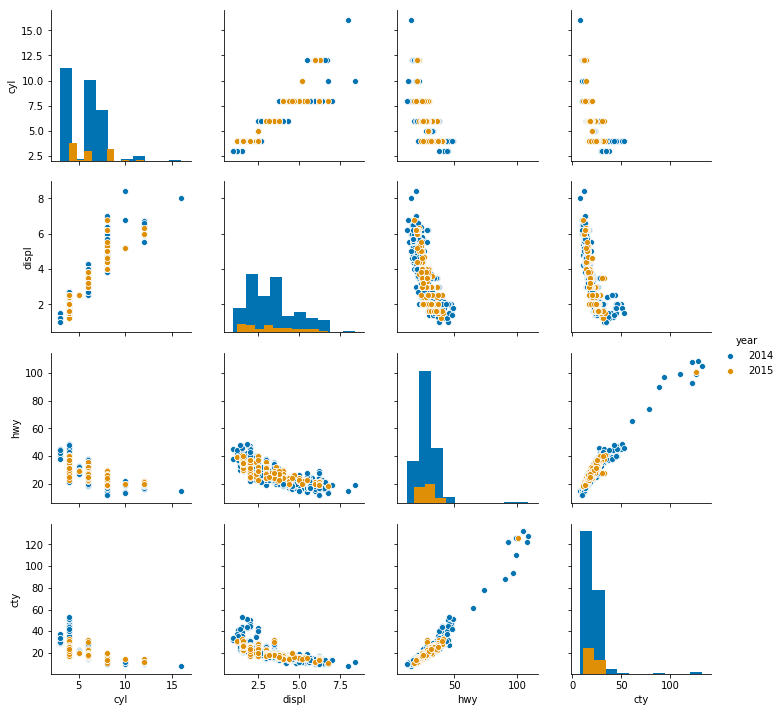

```python
df2['year'] = df2['year'].astype('str')
sns.pairplot(data = df2, vars = ['cyl', 'displ', 'hwy', 'cty'], hue = 'year', diag_kind = 'hist', palette = 'colorblind');
```

Certainly one of my favorite plots, the plot above combines the power of histograms to represent the distribution of the data with the power of scatter plots to show correlation. This is a very good tool for exploratory data analysis. The ability to also introduce categorical variables to visualize information across groups makes it even better